# Simple Linear Regression Tips Data set

#### Linear Regression

1. Introduction
2. Simple regression
   - Making predictions
   - Cost function
   - Gradient descent
   - Training
   - Model evaluation
   - Summary

### Introduction

Linear Regression is a supervised machine learning algorithm where the predicted output is continuous and has a constant slope. It’s used to predict values within a continuous range, (e.g. sales, price) rather than trying to classify them into categories (e.g. cat, dog). There are two main types:

**Simple regression**

Simple linear regression uses traditional slope-intercept form, where `m` and `b` are the variables our algorithm will try to “learn” to produce the most accurate predictions. `x` represents our input data and `y` represents our prediction.

[figure not shown]

**Multivariate or Multivariable Regression**

A more complex, multi-variable linear equation might look like this, where w represents the coefficients, or weights, our model will try to learn.

[figure not shown]

The variables `x`,`y`,`z` represent the attributes, or distinct pieces of information, we have about each observation. For `sales` **predictions**, these attributes might include a company’s advertising spend on `radio`, `TV`, and `newspapers`.

# Sales = w_1 Radio + w_2 TV + w_3 News

**Making predictions**

Our prediction function outputs an estimate of sales given a company’s radio advertising spend and our current values for Weight and Bias.

### Sales=Weight⋅Radio+Bias

**Weight**

The coefficient for the Radio independent variable. In machine learning we call coefficients weights.

**Radio**

The independent variable. In machine learning we call these variables features.

**Bias**

The intercept where our line intercepts the y-axis. In machine learning we can call intercepts bias. Bias offsets all predictions that we make.

Our algorithm will try to learn the correct values for Weight and Bias. By the end of our training, our equation will approximate the line of best fit.

```python
def predict_sales(radio, weight, bias):
    return weight*radio + bias
```

### Cost function

The prediction function is nice, but for our purposes we don’t really need it. What we need is a cost function so we can start optimizing our weights.

Let’s use MSE (L2) as our cost function. MSE measures the average squared difference between an observation’s actual and predicted values. The output is a single number representing the cost, or score, associated with our current set of weights. Our goal is to minimize MSE to improve the accuracy of our model.

**Math**

#### [Tip] Mean Square Error

In statistics, the mean squared error (MSE) or mean squared deviation (MSD) of an estimator (of a procedure for estimating an unobserved quantity) measures the average of the squares of the errors—that is, the average squared difference between the estimated values and the actual value. MSE is a risk function, corresponding to the expected value of the squared error loss. The fact that MSE is almost always strictly positive (and not zero) is because of randomness or because the estimator does not account for information that could produce a more accurate estimate [Reference](https://en.wikipedia.org/wiki/Mean_squared_error)

```python
def cost_function(radio, sales, weight, bias):
    companies = len(radio)
    total_error = 0.0
    for i in range(companies):
        total_error += (sales[i] - (weight*radio[i] + bias))**2
    return total_error / companies
```

### Gradient descent

**Math**

There are two parameters (coefficients) in our cost function we can control: weight m and bias b. Since we need to consider the impact each one has on the final prediction, we use partial derivatives. To find the partial derivatives, we use the Chain rule. We need the chain rule because

(y - (mx + b))^2 is really 2 nested functions: the inner function y - (mx + b) and the outer function x2

Returning to our cost function

[figure not shown]

**Code**

To solve for the gradient, we iterate through our data points using our new weight and bias values and take the average of the partial derivatives. The resulting gradient tells us the slope of our cost function at our current position (i.e. weight and bias) and the direction we should update to reduce our cost function (we move in the direction opposite the gradient). The size of our update is controlled by the learning rate.

```python
def update_weights(radio, sales, weight, bias, learning_rate):
    weight_deriv = 0
    bias_deriv = 0
    companies = len(radio)

    for i in range(companies):
        # Calculate partial derivatives
        # -2x(y - (mx + b))
        weight_deriv += -2*radio[i] * (sales[i] - (weight*radio[i] + bias))

        # -2(y - (mx + b))
        bias_deriv += -2*(sales[i] - (weight*radio[i] + bias))

    # We subtract because the derivatives point in direction of steepest ascent
    weight -= (weight_deriv / companies) * learning_rate
    bias -= (bias_deriv / companies) * learning_rate

    return weight, bias
```

#### Training

Training a model is the process of iteratively improving your prediction equation by looping through the dataset multiple times, each time updating the weight and bias values in the direction indicated by the slope of the cost function (gradient). Training is complete when we reach an acceptable error threshold, or when subsequent training iterations fail to reduce our cost.

Before training we need to initialize our weights (set default values), set our hyperparameters (learning rate and number of iterations), and prepare to log our progress over each iteration.

```python
def train(radio, sales, weight, bias, learning_rate, iters):
    cost_history = []

    for i in range(iters):
        weight,bias = update_weights(radio, sales, weight, bias, learning_rate)

        #Calculate cost for auditing purposes
        cost = cost_function(radio, sales, weight, bias)
        cost_history.append(cost)

        # Log Progress
        if i % 10 == 0:
            print("iter={:d}    weight={:.2f}    bias={:.4f}    cost={:.2}".format(i, weight, bias, cost))

    return weight, bias, cost_history
```

### Model evaluation

If our model is working, we should see our cost decrease after every iteration.

Logging

iter=1 weight=.03 bias=.0014 cost=197.25 iter=10 weight=.28 bias=.0116 cost=74.65 iter=20 weight=.39 bias=.0177 cost=49.48 iter=30 weight=.44 bias=.0219 cost=44.31 iter=30 weight=.46 bias=.0249 cost=43.28

[figure not shown]

## Cost history

[figure not shown]

### Summary

# Sales=.46Radio+.025

How would our model perform in the real world? I’ll let you think about it :)

```python
import numpy as np
import pandas as pd
import matplotlib.pyplot as plt
from sklearn import linear_model
```

```python
X = np.random.randn(10,2)
X
```

```
array([[ 1.01273378, -1.02108897],
       [ 0.12132544, -0.94606797],
       [ 0.68947991, -0.81844473],
       [-1.32227815, -0.59149297],
       [ 1.5033394 ,  0.54701565],
       [ 0.23356627, -0.21888959],
       [-0.80975372, -0.0198572 ],
       [ 0.03906703, -1.2976189 ],
       [-0.24559426,  0.67643173],
       [-0.08114688,  0.6616148 ]])
```

```python
Y = np.random.rand(10,2)
Y
```

```
array([[0.99766428, 0.35630037],
       [0.28225715, 0.98699383],
       [0.35681652, 0.76682951],
       [0.86207263, 0.14554814],
       [0.93264097, 0.37635115],
       [0.74607962, 0.49194822],
       [0.12173994, 0.6074441 ],
       [0.93958586, 0.05000606],
       [0.25400304, 0.35114827],
       [0.78227068, 0.73820839]])
```

```python
Model = linear_model.LinearRegression()
```

```python
Model
```

```
LinearRegression(copy_X=True, fit_intercept=True, n_jobs=None, normalize=False)
```

```python
Model.fit(X,Y)
```

```
LinearRegression(copy_X=True, fit_intercept=True, n_jobs=None, normalize=False)
```

```python
Model.coef_
```

```
array([[ 0.13259409, -0.07320555],
       [ 0.05002659,  0.04316684]])
```

```python
Model.intercept_
```

```
array([0.59021799, 0.49444371])
```

```python
Model.score(X,Y)
```

```
0.09091567928515075
```

```python
np.corrcoef(X,Y)
```

```
array([[ 1.,  1.,  1., -1.,  1.,  1., -1.,  1., -1., -1.,  1., -1., -1.,
         1.,  1.,  1., -1.,  1., -1.,  1.],
       [ 1.,  1.,  1., -1.,  1.,  1., -1.,  1., -1., -1.,  1., -1., -1.,
         1.,  1.,  1., -1.,  1., -1.,  1.],
       [ 1.,  1.,  1., -1.,  1.,  1., -1.,  1., -1., -1.,  1., -1., -1.,
         1.,  1.,  1., -1.,  1., -1.,  1.],
       [-1., -1., -1.,  1., -1., -1.,  1., -1.,  1.,  1., -1.,  1.,  1.,
        -1., -1., -1.,  1., -1.,  1., -1.],
       [ 1.,  1.,  1., -1.,  1.,  1., -1.,  1., -1., -1.,  1., -1., -1.,
         1.,  1.,  1., -1.,  1., -1.,  1.],
       [ 1.,  1.,  1., -1.,  1.,  1., -1.,  1., -1., -1.,  1., -1., -1.,
         1.,  1.,  1., -1.,  1., -1.,  1.],
       [-1., -1., -1.,  1., -1., -1.,  1., -1.,  1.,  1., -1.,  1.,  1.,
        -1., -1., -1.,  1., -1.,  1., -1.],
       [ 1.,  1.,  1., -1.,  1.,  1., -1.,  1., -1., -1.,  1., -1., -1.,
         1.,  1.,  1., -1.,  1., -1.,  1.],
       [-1., -1., -1.,  1., -1., -1.,  1., -1.,  1.,  1., -1.,  1.,  1.,
        -1., -1., -1.,  1., -1.,  1., -1.],
       [-1., -1., -1.,  1., -1., -1.,  1., -1.,  1.,  1., -1.,  1.,  1.,
        -1., -1., -1.,  1., -1.,  1., -1.],
       [ 1.,  1.,  1., -1.,  1.,  1., -1.,  1., -1., -1.,  1., -1., -1.,
         1.,  1.,  1., -1.,  1., -1.,  1.],
       [-1., -1., -1.,  1., -1., -1.,  1., -1.,  1.,  1., -1.,  1.,  1.,
        -1., -1., -1.,  1., -1.,  1., -1.],
       [-1., -1., -1.,  1., -1., -1.,  1., -1.,  1.,  1., -1.,  1.,  1.,
        -1., -1., -1.,  1., -1.,  1., -1.],
       [ 1.,  1.,  1., -1.,  1.,  1., -1.,  1., -1., -1.,  1., -1., -1.,
         1.,  1.,  1., -1.,  1., -1.,  1.],
       [ 1.,  1.,  1., -1.,  1.,  1., -1.,  1., -1., -1.,  1., -1., -1.,
         1.,  1.,  1., -1.,  1., -1.,  1.],
       [ 1.,  1.,  1., -1.,  1.,  1., -1.,  1., -1., -1.,  1., -1., -1.,
         1.,  1.,  1., -1.,  1., -1.,  1.],
       [-1., -1., -1.,  1., -1., -1.,  1., -1.,  1.,  1., -1.,  1.,  1.,
        -1., -1., -1.,  1., -1.,  1., -1.],
       [ 1.,  1.,  1., -1.,  1.,  1., -1.,  1., -1., -1.,  1., -1., -1.,
         1.,  1.,  1., -1.,  1., -1.,  1.],
       [-1., -1., -1.,  1., -1., -1.,  1., -1.,  1.,  1., -1.,  1.,  1.,
        -1., -1., -1.,  1., -1.,  1., -1.],
       [ 1.,  1.,  1., -1.,  1.,  1., -1.,  1., -1., -1.,  1., -1., -1.,
         1.,  1.,  1., -1.,  1., -1.,  1.]])
```

```python
from sklearn.metrics import r2_score,mean_squared_error,mean_absolute_error
```

#### [Tip] Error or Cost Funcation

- [Mean_Squared_Error](https://en.wikipedia.org/wiki/Mean_squared_error)
- Mean_percentage_error
- Mean_squared_prediction_error
- [Mean absolute error](https://en.wikipedia.org/wiki/Mean_absolute_error)
- [R_Square_Error](https://en.wikipedia.org/wiki/Coefficient_of_determination)

```python
R_erro = r2_score(X,Y)
R_erro
```

```
-0.824089047202119
```

```python
mean_squared_error(X,Y)
```

```
0.9858096965215917
```

```python
mean_absolute_error(X,Y)
```

```
0.7931163314387616
```

```python
import seaborn as sns
```

```python
Data = sns.load_dataset('tips')
Data.head()
```

|  | total_bill | tip | sex | smoker | day | time | size |
| --- | --- | --- | --- | --- | --- | --- | --- |
| 0 | 16.99 | 1.01 | Female | No | Sun | Dinner | 2 |
| 1 | 10.34 | 1.66 | Male | No | Sun | Dinner | 3 |
| 2 | 21.01 | 3.50 | Male | No | Sun | Dinner | 3 |
| 3 | 23.68 | 3.31 | Male | No | Sun | Dinner | 2 |
| 4 | 24.59 | 3.61 | Female | No | Sun | Dinner | 4 |

```python
Data.tail()
```

|  | total_bill | tip | sex | smoker | day | time | size |
| --- | --- | --- | --- | --- | --- | --- | --- |
| 239 | 29.03 | 5.92 | Male | No | Sat | Dinner | 3 |
| 240 | 27.18 | 2.00 | Female | Yes | Sat | Dinner | 2 |
| 241 | 22.67 | 2.00 | Male | Yes | Sat | Dinner | 2 |
| 242 | 17.82 | 1.75 | Male | No | Sat | Dinner | 2 |
| 243 | 18.78 | 3.00 | Female | No | Thur | Dinner | 2 |

```python
Data.describe()
```

|  | total_bill | tip | size |
| --- | --- | --- | --- |
| count | 244.000000 | 244.000000 | 244.000000 |
| mean | 19.785943 | 2.998279 | 2.569672 |
| std | 8.902412 | 1.383638 | 0.951100 |
| min | 3.070000 | 1.000000 | 1.000000 |
| 25% | 13.347500 | 2.000000 | 2.000000 |
| 50% | 17.795000 | 2.900000 | 2.000000 |
| 75% | 24.127500 | 3.562500 | 3.000000 |
| max | 50.810000 | 10.000000 | 6.000000 |

```python
Data.info()
```

```
<class 'pandas.core.frame.DataFrame'>
RangeIndex: 244 entries, 0 to 243
Data columns (total 7 columns):
total_bill    244 non-null float64
tip           244 non-null float64
sex           244 non-null category
smoker        244 non-null category
day           244 non-null category
time          244 non-null category
size          244 non-null int64
dtypes: category(4), float64(2), int64(1)
memory usage: 7.3 KB
```

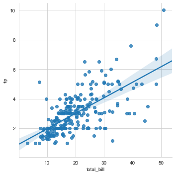

```python
sns.set_style('whitegrid')
sns.lmplot(x = 'total_bill', y = 'tip', data = Data)
```

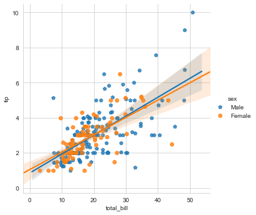

```python
sns.lmplot(x = 'total_bill', y = 'tip', data = Data, hue='sex', markers=['p','o'])
```

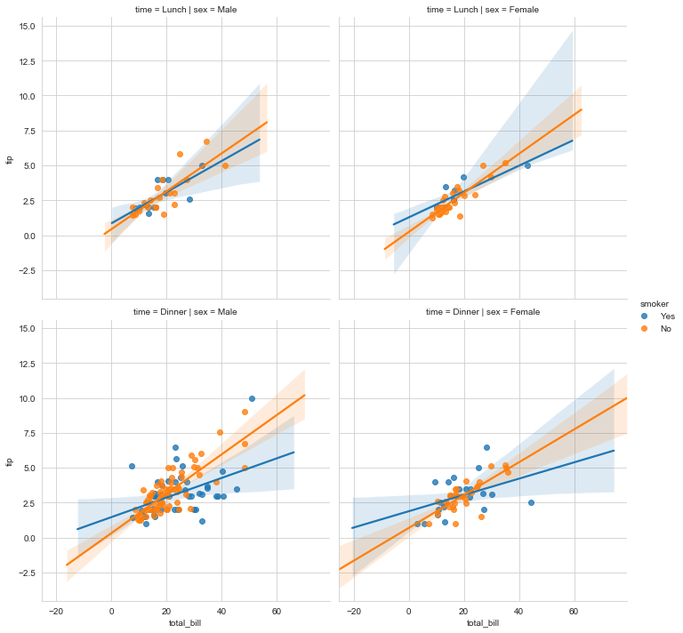

```python
sns.lmplot(x = 'total_bill', y = 'tip', data = Data, col='sex', row='time', hue='smoker')
```

```python
Data.columns
```

```
Index(['total_bill', 'tip', 'sex', 'smoker', 'day', 'time', 'size'], dtype='object')
```

```python
X_Data = Data[['total_bill']]
X_Data.head()
```

|  | total_bill |
| --- | --- |
| 0 | 16.99 |
| 1 | 10.34 |
| 2 | 21.01 |
| 3 | 23.68 |
| 4 | 24.59 |

```python
Y_Data = Data[['tip']]
Y_Data.head()
```

|  | tip |
| --- | --- |
| 0 | 1.01 |
| 1 | 1.66 |
| 2 | 3.50 |
| 3 | 3.31 |
| 4 | 3.61 |

```python
from sklearn.linear_model import LinearRegression
Modle = LinearRegression()
tips_model = Modle.fit(X_Data,Y_Data)
tips_model
```

```
LinearRegression(copy_X=True, fit_intercept=True, n_jobs=None, normalize=False)
```

```python
tips_model.coef_
```

```
array([[0.10502452]])
```

```python
tips_model.intercept_
```

```
array([0.92026961])
```

```python
tips_model.rank_
```

```
1
```

```python
tips_model.score(X_Data,Y_Data)
```

```
0.45661658635167657
```

#### if my total bill is 50$ then what is my tips?

```python
tips_model.predict([[50]])
```

```
array([[6.17149548]])
```

```python
tips_model.predict([[100]])    # Total Bill is 100
```

```
array([[11.42272135]])
```

```python
tips_model.predict([[150]]) # Total Bill is 150
```

```
array([[16.67394722]])
```

```python
from sklearn.model_selection import train_test_split
x_train,x_test,y_train,y_test = train_test_split(X_Data,Y_Data,test_size=0.3)
```

```python
x_train.shape
```

```
(170, 1)
```

```python
x_test.shape
```

```
(74, 1)
```

```python
y_train.shape
```

```
(170, 1)
```

```python
y_test.shape
```

```
(74, 1)
```

```python
Sk_Model = Model.fit(x_train,y_train)
Sk_Model
```

```
LinearRegression(copy_X=True, fit_intercept=True, n_jobs=None, normalize=False)
```

```python
Sk_Model.coef_
```

```
array([[0.10382077]])
```

```python
Sk_Model.intercept_
```

```
array([0.92285321])
```

```python
Sk_Model.score(x_train,y_train)
```

```
0.4337955743740575
```

```python
Y_Predicate = Sk_Model.predict(x_test)
Y_Predicate
```

```
array([[2.31093685],
       [2.86326332],
       [2.45732413],
       [1.99532172],
       [2.85807228],
       [3.02937655],
       [2.66911849],
       [1.51982261],
       [2.77190105],
       [2.02231512],
       [3.48826433],
       [2.81654398],
       [1.91953256],
       [2.5351897 ],
       [2.31612788],
       [5.19923055],
       [2.76878642],
       [3.66475963],
       [2.37634393],
       [3.21936855],
       [2.1552057 ],
       [3.57651198],
       [3.29204308],
       [3.32838035],
       [2.17077881],
       [2.27563779],
       [3.11970061],
       [1.72642593],
       [2.02854436],
       [3.73120492],
       [2.01400946],
       [2.82173501],
       [1.96832832],
       [5.93428157],
       [1.80636792],
       [2.18531372],
       [1.97040473],
       [2.06695805],
       [3.54017471],
       [4.58357341],
```

[output cut: 19 more lines]

```
       [3.07817231],
       [2.48639394],
       [3.25778223],
       [3.54744217],
       [3.47580584],
       [1.24158296],
       [1.99532172],
       [2.35661798],
       [2.40333733],
       [2.6442015 ],
       [4.87530976],
       [2.1012189 ],
       [2.56010668],
       [2.61201707],
       [3.42285725]])
```

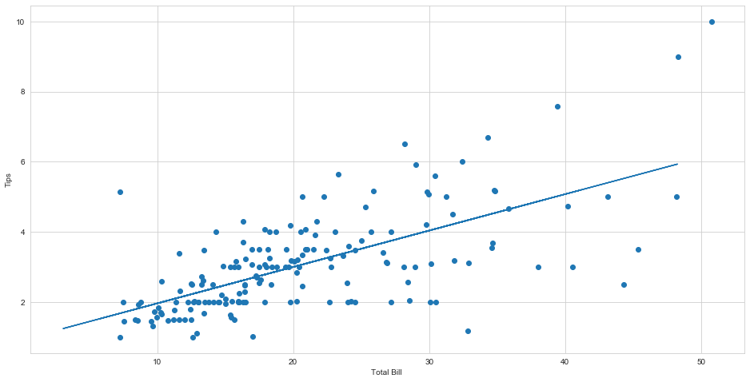

```python
fig,ax = plt.subplots(figsize=(16,8))
ax.scatter(x_train,y_train)
ax.plot(x_test,Y_Predicate)
ax.set_xlabel("Total Bill ")
ax.set_ylabel("Tips")
```

```python
tips_model.score(x_test,Y_Predicate)
```

```
0.9993714792184261
```

```python
from sklearn.metrics import mean_squared_error,adjusted_rand_score,mean_absolute_error
```

```python
mean_squared_error(y_test, Y_Predicate)
```

```
0.9507615810746641
```

```python
mean_absolute_error(y_test,Y_Predicate)
```

```
0.7349555715161593
```

```python
import statsmodels.formula.api as smf
import statsmodels.api as sm
```

```python
results = smf.ols('X_Data~Y_Data', data=Data).fit()
results
```

```
<statsmodels.regression.linear_model.RegressionResultsWrapper at 0x17138a3f9e8>
```

```python
print(results.summary())
```

```
                            OLS Regression Results
==============================================================================
Dep. Variable:                 X_Data   R-squared:                       0.457
Model:                            OLS   Adj. R-squared:                  0.454
Method:                 Least Squares   F-statistic:                     203.4
Date:                Thu, 03 Oct 2019   Prob (F-statistic):           6.69e-34
Time:                        16:17:32   Log-Likelihood:                -804.77
No. Observations:                 244   AIC:                             1614.
Df Residuals:                     242   BIC:                             1621.
Df Model:                           1
Covariance Type:            nonrobust
==============================================================================
                 coef    std err          t      P>|t|      [0.025      0.975]
------------------------------------------------------------------------------
Intercept      6.7503      1.006      6.707      0.000       4.768       8.733
Y_Data         4.3477      0.305     14.260      0.000       3.747       4.948
==============================================================================
Omnibus:                       58.831   Durbin-Watson:                   2.094
Prob(Omnibus):                  0.000   Jarque-Bera (JB):              120.799
Skew:                           1.185   Prob(JB):                     5.87e-27
Kurtosis:                       5.502   Cond. No.                         8.50
==============================================================================

Warnings:
[1] Standard Errors assume that the covariance matrix of the errors is correctly specified.
```

```python
tips_model.predict([[50]])
```

```
array([[6.17149548]])
```